# Ewing Sarcoma Gene Suppression RNA-Seq Analysis

Dec 28, 2022

Ewing sarcoma is a pediatric bone cancer which arises from the fusion of the EWSR1 and FLI1 genes (“EWSR1-FLI1” fusion oncogene). Recently, some have proposed therapies for Ewing sarcoma which suppress EWSR1-FLI1. This RNA-Seq analysis compares gene expression in an Ewing sarcoma cell line with and without EWS-FLI knockdown.

```r
# read in data
rse <- readRDS("EwS.rds")

# create DESeq data set
dds <- DESeqDataSet(rse, design = ~condition)
```

## Principal Components Plot

Data was first normalised using regularised log transformation (rlog). This was used to plot the first two principal components (PCs). The first PC separates the two conditions. This shows that a lot of the variation in gene expression in the dataset can likely be explained by the differences between experimental conditions and there are no other major sources of variation in the data that need to be accounted for.

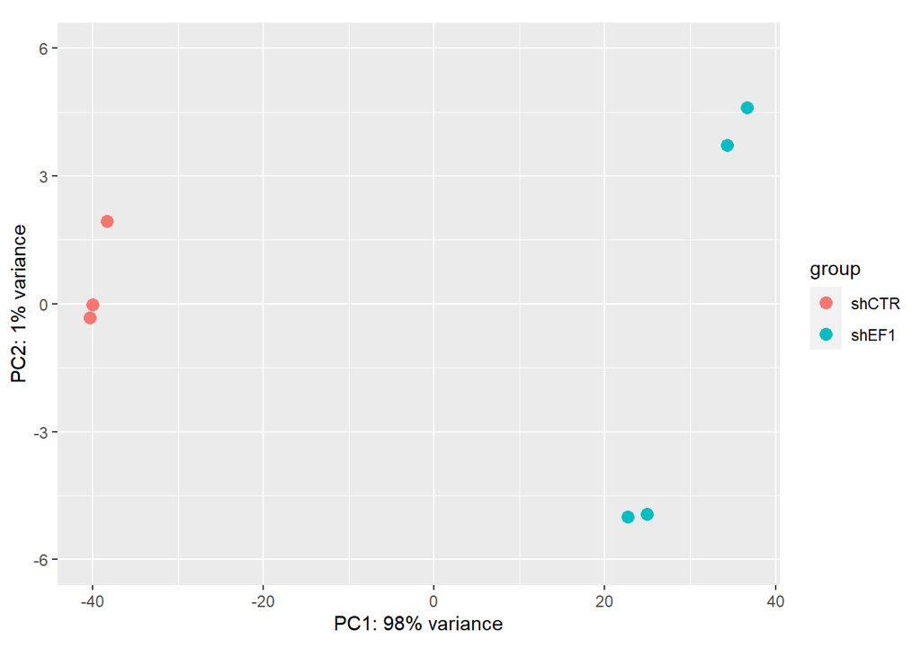

```r
# normalise data and plot PCA
rld <- rlog(dds)
plotPCA(rld) +
  coord_fixed(ratio = 5, ylim = c(-6, 6))
```

```r
# perform differential gene expression analysis
dds <- DESeq(dds)

# get results
res <- results(dds,
  contrast = c("condition", "shEF1", "shCTR"),
  alpha = 0.01
)
```

## MA Plot

To perform differential gene expression analysis, raw counts for each gene were fit to the DESeq negative binomial model. An MA plot was produced to visualise the results. The MA plot shows the average expression of each gene versus the log2 fold change. The points are coloured blue if the adjusted p-value is less than 0.01. Log fold change (LFC) shrinkage was performed using the apeglm method. This method is designed to reduce the bias in log fold change estimates caused by low average expression levels.

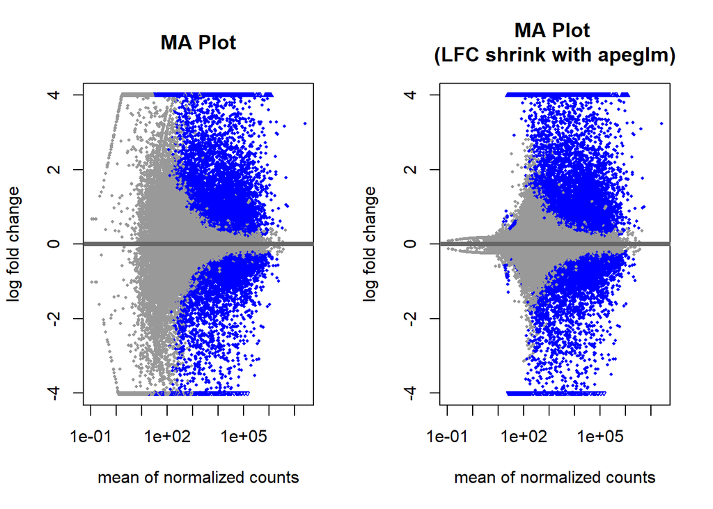

```r
# plot MA plot with and without LFC shrink side by side
par(mfrow = c(1, 2))

plotMA(res, ylim = c(-4, 4), main = "MA Plot")

res_norm <- lfcShrink(
  dds = dds, res = res,
  type = "apeglm", coef = 2
)
plotMA(res_norm,
  ylim = c(-4, 4),
  main = "MA Plot \n(LFC shrink with apeglm)"
)
```

## Differentially Expressed Genes

Differentially expressed genes were defined as those with an adjusted p-value less than 0.01, a log2 fold change of at least 1, and an average expression level of at least 20 counts. A table of the resulting differentially expressed genes is shown below.

```r
# make dataframe
res_df <- as.data.frame(res_norm)

# convert ENSG to gene symbol
ENS_to_symbol <- AnnotationDbi::select(EnsDb.Hsapiens.v86,
  keys = keys(EnsDb.Hsapiens.v86),
  columns = c("SYMBOL", "ENTREZID")
)

# join res_df with ENS_to_symbol
res_df <- res_df %>%
  rownames_to_column() %>%
  # remove version number from ENSG
  mutate(GENEID = gsub(rowname, pattern = "\\..+", replacement = "")) %>%
  dplyr::select(-rowname) %>%
  inner_join(y = ENS_to_symbol, by = "GENEID") %>%
  dplyr::select(GENEID, SYMBOL, ENTREZID, everything()) # reorder columns

# get significant results
sig_res <- res_df %>%
  filter(padj < 0.01 & # (adjusted p-value threshold)
    abs(log2FoldChange) >= 1 & # (at least 2 fold)
    baseMean >= 20) # (average expression level (at least 20 counts))

sig_res_clean <- sig_res %>%
  dplyr::select(SYMBOL, log2FoldChange, pvalue, padj, baseMean) %>%
  arrange(desc(padj)) %>%
  mutate_at(vars(pvalue, padj), formatC, format = "e", digits = 2) %>%
  mutate_at(vars(log2FoldChange, baseMean), round, 2)

# use DT to create table
datatable(sig_res_clean,
  options = list(pageLength = 10),
  colnames = c(
    "Gene Symbol", "log 2 fold change",
    "Wald test p-value", "BH adjusted p-value", "Mean of normalised counts"
  )
)
```

|  | Gene Symbol | log 2 fold change | Wald test p-value | BH adjusted p-value | Mean of normalised counts |
| --- | --- | --- | --- | --- | --- |
| 1 | SSX9 | -2.35 | 3.42e-03 | 9.94e-03 | 353.61 |
| 2 | AC009784.3 | -3.01 | 3.40e-03 | 9.87e-03 | 212.58 |
| 3 | NFE2L3P1 | 1.22 | 3.40e-03 | 9.87e-03 | 565.77 |
| 4 | NPR1 | -1.13 | 3.36e-03 | 9.79e-03 | 388.32 |
| 5 | PGLYRP2 | -3.21 | 3.34e-03 | 9.73e-03 | 2788.61 |
| 6 | RP11-155G14.5 | -1.04 | 3.33e-03 | 9.71e-03 | 624.82 |
| 7 | RP11-302B13.1 | 1.02 | 3.31e-03 | 9.64e-03 | 609.66 |
| 8 | LINC01629 | 2.91 | 3.29e-03 | 9.59e-03 | 204.58 |
| 9 | GBGT1 | 1.63 | 3.29e-03 | 9.58e-03 | 451.81 |
| 10 | ASS1P9 | 2.39 | 3.28e-03 | 9.56e-03 | 1262 |

[output cut: 5234 more lines]

## Volcano Plot

A volcano plot was created to look at the distribution of fold changes relative to the adjusted p-value.

```r
EnhancedVolcano(res_df,
  lab = res_df$SYMBOL, pCutoff = 0.01,
  FCcutoff = 1, x = "log2FoldChange", y = "padj",
  title = "Control vs EWS-FLI knockdown"
)
```

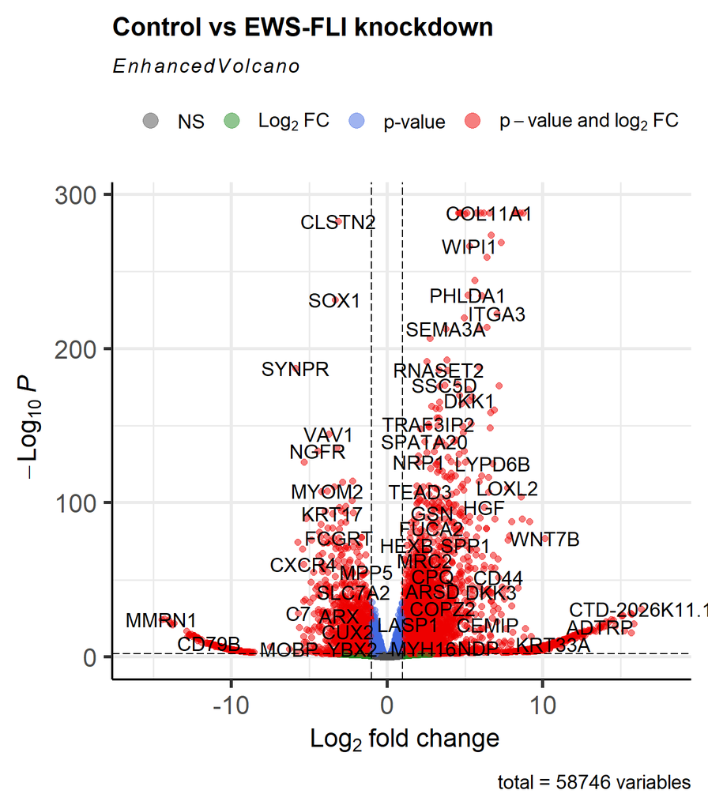

## Top 20 Differentially Expressed Genes

The heatmap below looks at the top 10 over-expressed genes and the top 10 under-expressed genes based on log2 fold change obtained after LFC shrinkage. rlog normalised counts for each gene were used.

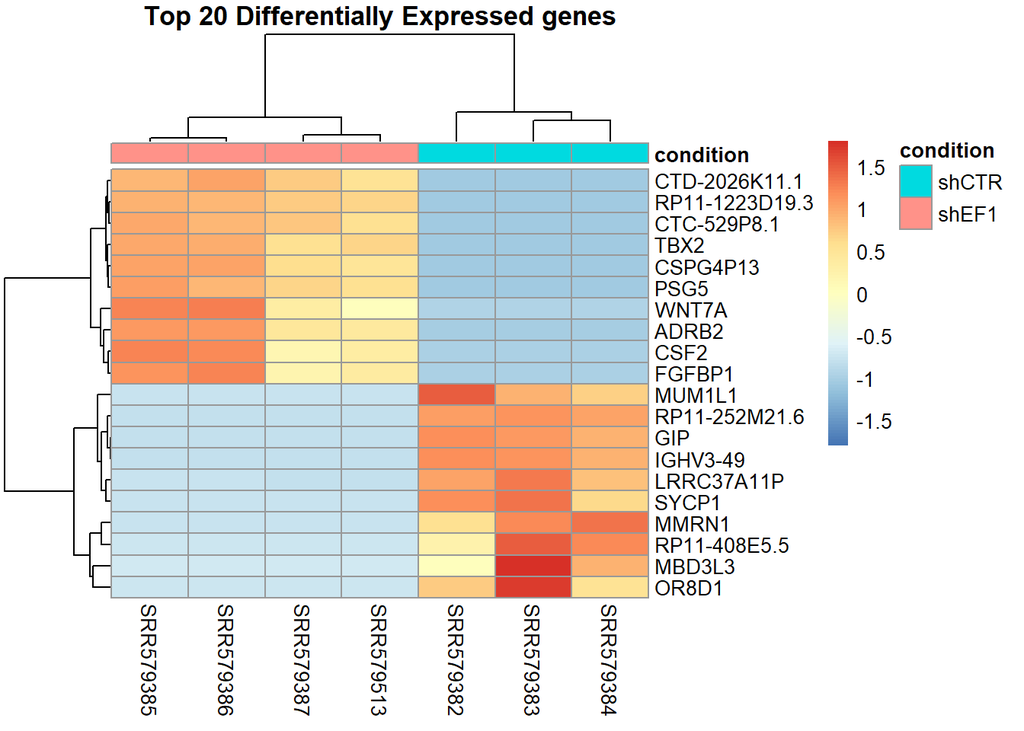

```r
# top 10 over-expressed genes
top10_over <- sig_res %>%
  arrange(desc(log2FoldChange)) %>%
  head(10)

# top 10 under-expressed genes
top10_under <- sig_res %>%
  arrange(log2FoldChange) %>%
  head(10)

top20 <- rbind(top10_over, top10_under)

# subset the top20 genes from the normalised counts
id1 <- top20$GENEID
id2 <- top20$SYMBOL

normalised_counts <- assay(rld) %>%
  as.data.frame() %>%
  rownames_to_column() %>%
  mutate(GENEID = gsub(rowname, pattern = "\\..+", replacement = "")) %>%
  dplyr::select(-rowname) %>%
  dplyr::distinct(GENEID, .keep_all = TRUE) %>%
  tibble::column_to_rownames("GENEID")

topDE <- normalised_counts[id1, ]
rownames(topDE) <- id2

# create a dataframe with the condition annotation
condition_annotation <- colData(rse)$condition %>%
  as.data.frame()
colnames(condition_annotation) <- "condition"
row.names(condition_annotation) <- colnames(topDE)

pheatmap(topDE,
  cluster_rows = T,
  annotation_col = condition_annotation,
  scale = "row",
  main = "Top 20 Differentially Expressed genes"
)
```

## Gene Set Enrichment Analysis

Gene Set Enrichment Analysis (GSEA) was performed to identify enriched gene sets in KEGG pathways. The GSEA metric was calculated as follows: gsea metric = -log10(padj) * sign(log2FoldChange). The results of the GSEA analysis are shown in the table below.

```r
# Deal with infinity values of pajd and add GSEA score
res_for_gsea <- res_df %>%
  mutate(padj = case_when(
    padj == 0 ~ .Machine$double.xmin,
    TRUE ~ padj
  )) %>%
  mutate(gsea_metric = -log10(padj) * sign(log2FoldChange)) %>%
  filter(!is.na(gsea_metric)) %>%
  arrange(desc(gsea_metric))

# Get the ranked GSEA vector
ranks <- res_for_gsea %>%
  select(ENTREZID, gsea_metric) %>%
  distinct(ENTREZID, .keep_all = TRUE) %>%
  deframe()

# Run GSEA
gsea_res <- gseKEGG(ranks, organism = "hsa")
gsea_res_df <- as.data.frame(gsea_res)
```

```r
gsea_res_clean <- gsea_res_df %>%
  dplyr::select(ID, Description, setSize, enrichmentScore, NES, pvalue, p.adjust) %>%
  rownames_to_column() %>%
  dplyr::select(-rowname) %>%
  column_to_rownames("ID") %>%
  arrange(desc(NES)) %>%
  mutate_at(vars(pvalue, p.adjust), formatC, format = "e", digits = 2) %>%
  mutate_at(vars(enrichmentScore, NES), round, 2)

# use DT to create table
datatable(gsea_res_clean,
  options = list(pageLength = 10),
  colnames = c(
    "Pathway", "Gene Set Size", "Enrichment Score",
    "Normalised Enrichment Score", "p-value", "BH adjusted p-value"
  )
)
```

|  | Pathway | Gene Set Size | Enrichment Score | Normalised Enrichment Score | p-value | BH adjusted p-value |
| --- | --- | --- | --- | --- | --- | --- |
| hsa04512 | ECM-receptor interaction | 84 | 0.87 | 1.76 | 5.05e-09 | 1.69e-06 |
| hsa04640 | Hematopoietic cell lineage | 70 | 0.83 | 1.65 | 1.95e-05 | 8.65e-04 |
| hsa05144 | Malaria | 41 | 0.85 | 1.63 | 3.23e-04 | 9.84e-03 |
| hsa04630 | JAK-STAT signaling pathway | 122 | 0.77 | 1.58 | 2.06e-05 | 8.65e-04 |
| hsa04510 | Focal adhesion | 198 | 0.75 | 1.58 | 1.41e-06 | 1.13e-04 |
| hsa04974 | Protein digestion and absorption | 90 | 0.75 | 1.52 | 2.08e-03 | 3.76e-02 |
| hsa04151 | PI3K-Akt signaling pathway | 319 | 0.72 | 1.52 | 4.30e-07 | 5.77e-05 |
| hsa05410 | Hypertrophic cardiomyopathy | 84 | 0.75 | 1.52 | 1.16e-03 | 2.44e-02 |
| hsa04380 | Osteoclast differentiation | 113 | 0.74 | 1.51 | 4.57e-04 | 1.26e-02 |
| hsa05222 | Small cell lung cancer | 90 | 0.74 | 1.51 | 2.80e-03 | 4.14e-02 |

[output cut: 23 more lines]

```r
# function for plotting gsea results from a list containing 4 pathways
gsea_multiplot <- function(pathways_id_list) {
  gsea_plots_list <- list()

  # gseaplot creates 2 plots for each pathway
  # first we store the plots in a list of lists
  # i.e. gsea_plots_list[[1]] = list of plots for pathway 1 which contains 2 plots
  for (ID in pathways_id_list) {
    p <- gseaplot(gsea_res, geneSetID = ID, title = gsea_res[ID, "Description"])
    p[[1]] <- p[[1]] + ylab("Ranked \nList Metric")
    p[[2]] <- p[[2]] + ylab("Running \nEnrichment Score")
    p <- ggpar(p,
      font.main = c(9, "bold"),
      font.axis = 10, font.x = 10, font.y = 10, font.tickslab = 8
    )
    gsea_plots_list[[ID]] <- p
  }

  # both plots for each pathway are arranged in 1 column
  paired_plots <- lapply(1:4, function(i) {
    ggarrange(plotlist = gsea_plots_list[[i]], nrow = 2, ncol = 1)
  })

  # the 4 pathways are arranged in a 2x2 grid
  ggarrange(
    plotlist = paired_plots,
    nrow = 2, ncol = 2, labels = "AUTO", font.label = 10
  )
}
```

### Top 4 over-expressed pathways

The top 4 over-expressed pathways based on normalised enrichment score (NES) are shown below.

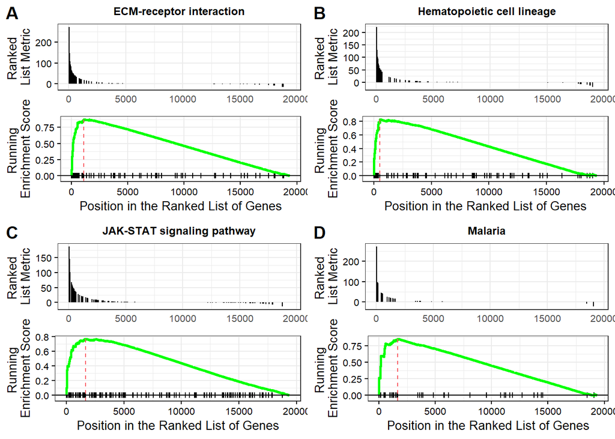

```r
# Get top 4 over-expressed pathways
top_pathway_IDs <- gsea_res_df %>%
  top_n(n = 4, wt = NES) %>%
  pull(ID)

# Plot the top 4 over-expressed pathways
gsea_multiplot(top_pathway_IDs)
```

### Bottom 4 under-expressed pathways

The top 4 under-expressed pathways with the lowest NES are shown below.

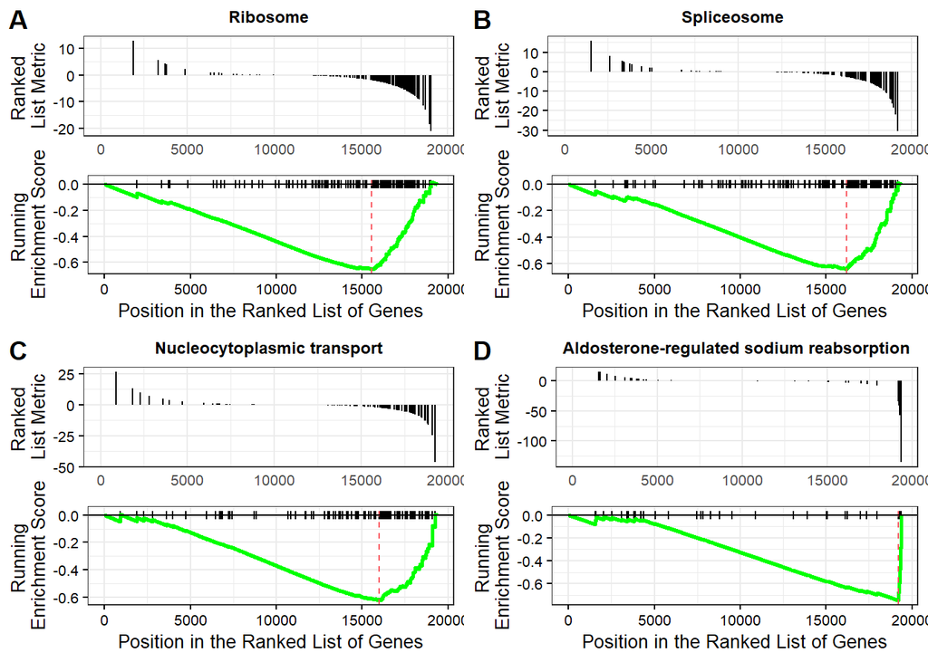

```r
# Repeat steps with top 4 under-expressed pathways
bottom_pathway_IDs <- gsea_res_df %>%
  top_n(n = 4, wt = -NES) %>%
  pull(ID)

gsea_multiplot(bottom_pathway_IDs)
```